# Experimental Sociology - Week 06 - In Class

Evolutionary ABMs: Complex

Published

2025-05-14

# Task 1: How many **GT** are needed to **displace PP**?

## Prepare

```r
model <- list(
  b = 3,
  c = 1,
  error = 0,
  noise = 0,
  n = 100,
  memory = 1,
  expected_rounds = c(15, 15),
  seed = 42,
  mu = 0.05,
  mu_rnd = 0.05,
  w  = 5,
  mutators_n_fixed = FALSE,
  max_t = 2500
)
source("../data/abm-pd2/functions_sequence.R", chdir = TRUE)
```

## The Code

```r
world <- init_world(model)
world$strat_mat[,] <- rep(c(0,1,0,0,1), each = nrow(world$strat_mat))
GT_max = 99 # the number of maximum GT strategies
df_fit <- data.frame(
  n_GT       = 1:GT_max,
  fitness_GT = numeric(GT_max),   # agent 1’s fitness each run
  fitness_PP = numeric(GT_max)    # agent 100’s fitness each run
)
for (i in 1:GT_max) {
  world$strat_mat[i,] <- c(1,0,0,0,1)  # add another GT
  result <- run_step_fast_cpp(world, model) # run the step
  df_fit$fitness_GT[i] <- result$agents[1,   "fitness"]
  df_fit$fitness_PP[i] <- result$agents[100, "fitness"]
}
df_fit |> filter( fitness_GT > fitness_PP) |> slice_head(n=5)
```

## Result

```r
world <- init_world(model)

# change all strategies to PP (01001)
world$strat_mat[,] <- rep(c(0,1,0,0,1), each = nrow(world$strat_mat))

# the number of maximum GT strategies
GT_max = 99

df_fit <- data.frame(
  n_GT       = 1:GT_max,
  fitness_GT = numeric(GT_max),   # agent 1’s fitness each run
  fitness_PP = numeric(GT_max)    # agent 100’s fitness each run
)

# Run the simulation 10 times
for (i in 1:GT_max) {
  # add another GT
  world$strat_mat[i,] <- c(1,0,0,0,1)

  ## run the step
  result <- run_step_fast_cpp(world, model)

  ## store the two fitness values
  df_fit$fitness_GT[i] <- result$agents[1,   "fitness"]
  df_fit$fitness_PP[i] <- result$agents[100, "fitness"]
}

df_fit |> filter( fitness_GT > fitness_PP) |> slice_head(n=5)
```

```
  n_GT fitness_GT fitness_PP
1   20   1.461279   1.435690
2   21   1.468013   1.414141
3   22   1.474747   1.392593
4   23   1.481481   1.371044
5   24   1.488215   1.349495
```

# How many **GT** are required to achieve **higher fitness than aD?**

## Code

```r
world <- init_world(model)
world$strat_mat[,] <- rep(c(0,0,0,0,0), each = nrow(world$strat_mat))
GT_max = 99
df_fit <- data.frame(
  n_GT       = 1:GT_max,
  fitness_GT = numeric(GT_max),   # agent 1’s fitness each run
  fitness_aD = numeric(GT_max)    # agent 100’s fitness each run
)
for (i in 1:GT_max) {
  world$strat_mat[i,] <- c(1,0,0,0,1)
  result <- run_step_fast_cpp(world, model)
  df_fit$fitness_GT[i] <- result$agents[1,   "fitness"]
  df_fit$fitness_aD[i] <- result$agents[100, "fitness"]
}
df_fit |> filter( fitness_GT > fitness_aD) |> slice_head(n=5)
```

## Result

```r
world <- init_world(model)

# change all strategies to aD (00000)
world$strat_mat[,] <- rep(c(0,0,0,0,0), each = nrow(world$strat_mat))

# the number of maximum GT strategies
GT_max = 99

df_fit <- data.frame(
  n_GT       = 1:GT_max,
  fitness_GT = numeric(GT_max),   # agent 1’s fitness each run
  fitness_aD = numeric(GT_max)    # agent 100’s fitness each run
)

# Run the simulation 10 times
for (i in 1:GT_max) {
  # add another GT
  world$strat_mat[i,] <- c(1,0,0,0,1)

  ## run the step
  result <- run_step_fast_cpp(world, model)

  ## store the two fitness values
  df_fit$fitness_GT[i] <- result$agents[1,   "fitness"]
  df_fit$fitness_aD[i] <- result$agents[100, "fitness"]
}

df_fit |> filter( fitness_GT > fitness_aD) |> slice_head(n=5)
```

```
  n_GT fitness_GT fitness_aD
1    5 0.01683502 0.01010101
2    6 0.03771044 0.01212121
3    7 0.05858586 0.01414141
4    8 0.07946128 0.01616162
5    9 0.10033670 0.01818182
```

# Errors

## Win-Stay-Lose-Shift

The **Win-Stay, Lose-Shift (WSLS)** strategy — represented by the bit string `11001` — begins with cooperation and then **sticks with its current behavior if the outcome is favorable**, and **switches if it is not**. Specifically, it continues cooperating if it receives either of the **high-payoff outcomes**: $b$ (when the other cooperates while it defects) or $b - c$ (mutual cooperation). If it receives one of the **low-payoff outcomes** — either $0$ (mutual defection) or $-c$ (it cooperates while the other defects) — it switches its action in the next round.

WSLS has a nice property in comparison to GT and TFT:

## GT vs GT

- When **Grim Trigger** (GT) plays against itself, a single mistake can lead to **eternal defection**:
  - Example:
    - Player A: $C, C, D^*, C, D, D, D, \dots$
    - Player B: $C, C, C, D, D, D, D, \dots$
  - After one accidental defection ($D^*$), both players switch to permanent defection, as GT never forgives once trust is broken.
  - The only way cooperation can resume is if **both agents simultaneously make an error** and accidentally cooperate.

## TFT vs TFT

- **Tit-for-Tat** (TFT) is slightly more forgiving, but still vulnerable to cycles of retaliation:
  - Example:
    - Player A: $C, C, D^*, C, D, C, D, \dots$
    - Player B: $C, C, C, D, C, D, C, \dots$
  - The mistake causes a chain reaction of alternating $C$ and $D$.
  - A **second error** at the right time can either restore mutual cooperation ($C, C$) or plunge the system into mutual defection ($D, D$).
  - In the latter case only simultaneous errors can save the cooperation.

## Evolutionary Dynamics

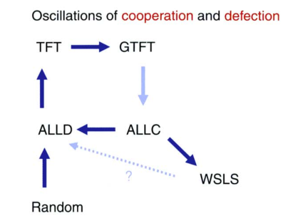

Evolutionary dynamics in world with error a (Nowak 2006: 91)

- Lets check this out!

## Setup

```r
model <- within(model, {
    error = 0.05
  })
```

## First Sim: Only GT

```r
world <- init_world(model)

# change all strategies to GT (10001)
world$strat_mat[,] <- rep(c(1,0,0,0,1), each = nrow(world$strat_mat))

df_fit <- data.frame(fitness_GT = numeric())

# Replicate the simulation 20 times
for (r in 1:20) {
  ## run the step
  result <- run_step_rnd_err_cpp(world, model)

  ## store the two fitness values
  df_fit <- rbind(df_fit, data.frame(fitness_GT = result$agents |> select(fitness)))
}
fitness_GT <- df_fit |> summary()
```

## Now with TFT

```r
world <- init_world(model)

# change all strategies to TFT (100!1)
world$strat_mat[,] <- rep(c(1,0,0,1,1), each = nrow(world$strat_mat))

df_fit <- data.frame(fitness_TFT = numeric())

# Replicate the simulation 20 times
for (r in 1:20) {
  ## run the step
  result <- run_step_rnd_err_cpp(world, model)

  ## store the two fitness values
  df_fit <- rbind(df_fit, data.frame(fitness_TFT = result$agents |> select(fitness)))
}

fitness_TFT <- df_fit |> summary()
```

## Now With Win-Stay-Lose-Shift

```r
world <- init_world(model)

# change all strategies to WSLS (11001)
world$strat_mat[,] <- rep(c(1,1,0,0,1), each = nrow(world$strat_mat))

df_fit <- data.frame(fitness_WSLS = numeric())

# Replicate the simulation 20 times
for (r in 1:20) {
  ## run the step
  result <- run_step_rnd_err_cpp(world, model)

  ## store the two fitness values
  df_fit <- rbind(df_fit, data.frame(fitness_WSLS = result$agents |> select(fitness)))
}

fitness_WSLS <- df_fit |> summary()
```

## Comparison

```r
cbind(fitness_GT,fitness_TFT,fitness_WSLS)
```

```
    fitness           fitness           fitness
 "Min.   :1.207  " "Min.   :1.531  " "Min.   :1.762  "
 "1st Qu.:1.401  " "1st Qu.:1.652  " "1st Qu.:1.816  "
 "Median :1.447  " "Median :1.679  " "Median :1.830  "
 "Mean   :1.445  " "Mean   :1.679  " "Mean   :1.829  "
 "3rd Qu.:1.488  " "3rd Qu.:1.707  " "3rd Qu.:1.842  "
 "Max.   :1.668  " "Max.   :1.814  " "Max.   :1.890  "
```

- **Win-Stay, Lose-Shift (WSLS)** is one effective strategy for dealing with noisy or error-prone environments.
- The longer the **expected number of rounds** in the repeated game, the more effective WSLS becomes:
  - With more rounds, there’s more time for agents to recover from mistakes and re-establish cooperation.
  - Occasional missteps matter less in the long run, as WSLS can correct and maintain cooperation over time.

## Or can it?

```r
world <- init_world(model)

# change all strategies to WSLS (11001)
world$strat_mat[,] <- rep(c(1,1,0,0,1), each = nrow(world$strat_mat))

for (t in 1:10000) {
    world <- run_step_rnd_err_cpp(world, model)
    world <- update_agents(world, model)
}

summarise_strategies(world)
```

```
# A tibble: 4 × 3
  strat_id share fitness_mean
  <chr>    <dbl>        <dbl>
1 01001     0.97        1.69
2 01101     0.01        1.47
3 01010     0.01        1.10
4 10011     0.01        0.756
```

# More Complex Strategies

## Well …

- Encountered several challenges:
  - Two main approaches to expanding strategy complexity:
    - `Memory=2`: $2^{21}=2097152$ strategies
    - Instead of 0/1, probabilistic strategies 0/0.1/0.2/…/1: $11^5=161051$ strategies
  - Evolutionary convergence takes longer
    - Simulations require more steps to stabilize
    - This increases runtime and resource demands in real life
    - To manage memory: store less data, e.g., saving only every *n*-th step
    - Interpreting results becomes more challenging
  - A lot of changes in the code were necessary :-/

## Copyright

Copyright Sascha Grehl, 2025. All Rights Reserved